# 3. Posterior predictive and prior predictive sampling

## Rethink the prior for $\mu$

- The average adult male is 176.5 cm
- the average adult female is 163 cm
- Maybe we should set $\mu = \frac{176.5 + 163}{2} = 169.75$

## One more parameter needed

How certain are we that the true mean for this sample will be equal to 169.75?

## Simulate 4 priors for $\mu$

```r
all_the_priors <- data.frame(
  sigma1 = rnorm(1e4, 169.75, 1),
  sigma2 = rnorm(1e4, 169.75, 2),
  sigma10 = rnorm(1e4, 169.75, 10),
  sigma25 = rnorm(1e4, 168.75, 25))
```

## Distributions of priors for $\mu$

```r
all_the_priors |>
  pivot_longer(cols = everything()) |>
  ggplot(aes(x = value * 0.0328084, color = name)) +
  geom_density(alpha = 0.1) +
  labs(x = "Height in feet", color = "Mu prior")
```

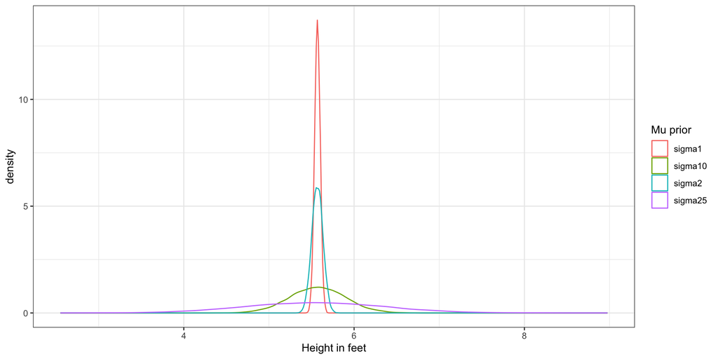

## Now for $\sigma$

- How much do individuals vary on average from the population average? How variable is height?
- Recall $sd = \sqrt{\frac{\sum{(x_i - \mu)^2}}{n}}$
- The average deviation of an observation from the mean
- $\sigma$ is constrained to be positive, our prior should reflect this

## The impact of $\sigma$ on our prior

Our prior for $\sigma$ captures our beliefs about how much variance there is within the population.

*How much variable is height across adults?*

- No idea how variable the population is: $\sigma \sim \textsf{Uniform}(0,50)$
- We know there’s not much variation: $\sigma \sim \textsf{Uniform}(0,10)$

## Understanding the prior: prior predictive simulation

1. Simulate $\mu$

```r
### simulate mu prior: mu ~ N(169.75, 25)
mu_sims<-rnorm(1e4, 169.75, 25)
```

2. Simulate $\sigma$

```r
### simulate sigma prior: sigma ~ U(0,50)
sigma_sims<-runif(1e4, 0, 50)
```

3. Draw predictions from $N(\mu, \sigma)$

```r
### prior predictive distribution: y~N(mu, sigma)
height_preds<-rnorm(1e4, mu_sims, sigma_sims)
```

## Simulating data from the prior

Is our prior reasonable?

```r
data.frame(x = height_preds) |>
  ggplot(aes(x = x * 0.032)) + geom_density() + labs(caption = "height in feet")
```

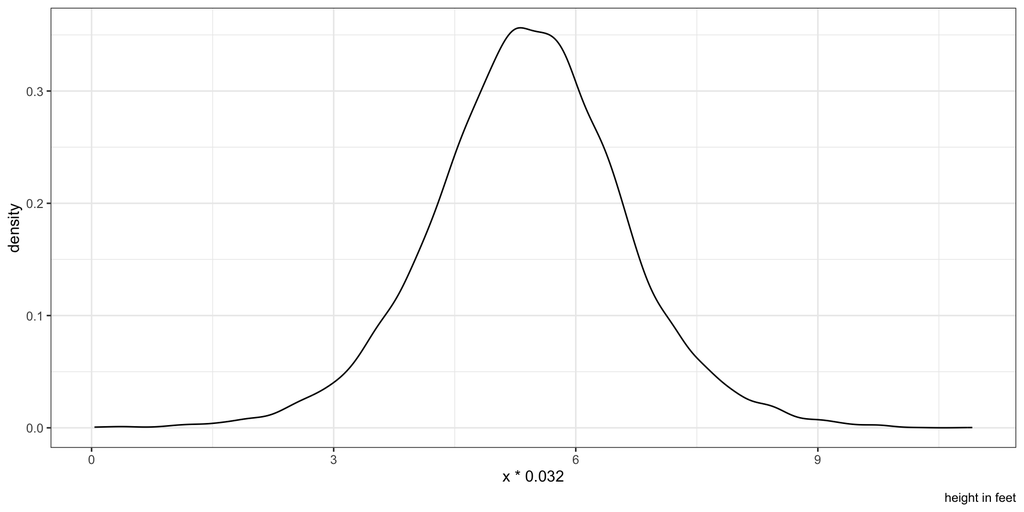